# Problem Set 01 Notebook

Nigarhan Gurpinar

(February 12, 2018)

## Introduction

This is the first problem set’s R Notebook for the course SOC 4650/5650: Introduction to GISc!

## Project Set Up

```r
knitr::opts_knit$set(root.dir = here::here())
```

## Load Dependencies

```r
library(tidyverse)
library(dplyr)
library(readr)
library(janitor)
library(naniar)
library(readr)
```

## Load Data

The following code loads the data package and assigns our data to a data frame in our global environment:

```r
damsRaw <- read_csv("data/MO_HYDRO_Dams.csv") # data source
DamsTibble <- as_tibble (damsRaw)
```

## Part 1

### Question 7

First, I’m going to rename variables camelCase en masse and change some variables’ names.

```r
DamsTibble %>%
  clean_names(case = "small_camel") %>%
  rename(id = objectid) %>%
  rename(name = offname) %>%
  rename(ownType = owntype) %>%
  rename(damType = damtype) %>%
  rename(yearComplete = yrcmplt) %>%
  rename(height = damht) -> DamsTibble
```

### Question 8

The following code reveals if any of the variables have missing data or not.

```r
miss_var_summary(DamsTibble)
```

| variable | n_missing | percent |
| --- | --- | --- |
| purpose | 155 | 2.94061848 |
| damType | 2 | 0.03794346 |
| id | 0 | 0.00000000 |
| nidId | 0 | 0.00000000 |
| name | 0 | 0.00000000 |
| regulated | 0 | 0.00000000 |
| latitude | 0 | 0.00000000 |
| longitude | 0 | 0.00000000 |
| county | 0 | 0.00000000 |
| ownType | 0 | 0.00000000 |

[output cut: 5 more lines]

‘purpose’ and ‘damType’ variables has some missing data.

### Question 9

The following code reveals if any of the observations have missing data or not.

```r
miss_case_summary(DamsTibble)
```

| case | n_missing | percent |
| --- | --- | --- |
| 1830 | 2 | 13.333333 |
| 1831 | 2 | 13.333333 |
| 465 | 1 | 6.666667 |
| 1080 | 1 | 6.666667 |
| 1618 | 1 | 6.666667 |
| 1682 | 1 | 6.666667 |
| 1683 | 1 | 6.666667 |
| 1694 | 1 | 6.666667 |
| 1695 | 1 | 6.666667 |
| 1709 | 1 | 6.666667 |

[output cut: 990 more lines]

### Question 10

The following code creates a duplicate observation report for the entire data frame.

```r
get_dupes(DamsTibble)
```

```
No variable names specified - using all columns.

No duplicate combinations found of: id, nidId, name, regulated, latitude, longitude, county, ownType, damType, ... and 6 other variables
```

| id | nidId | name | regulated | latitude | longitude | county | ownType | damType | purpose | yearComplete | height | maxstor | resarea | wtrshed | dupe_count |
| --- | --- | --- | --- | --- | --- | --- | --- | --- | --- | --- | --- | --- | --- | --- | --- |

There are no duplicates.

### Question 11

The following code creates a duplicate observation report for id variable.

```r
get_dupes(DamsTibble, id)
```

```
No duplicate combinations found of: id
```

| id | dupe_count | nidId | name | regulated | latitude | longitude | county | ownType | damType | purpose | yearComplete | height | maxstor | resarea | wtrshed |
| --- | --- | --- | --- | --- | --- | --- | --- | --- | --- | --- | --- | --- | --- | --- | --- |

There are no duplicates.

### Question 12

The following code creates a duplicate observation report for nidId variable.

```r
get_dupes(DamsTibble, nidId)
```

| nidId | dupe_count | id | name | regulated | latitude | longitude | county | ownType | damType | purpose | yearComplete | height | maxstor | resarea | wtrshed |
| --- | --- | --- | --- | --- | --- | --- | --- | --- | --- | --- | --- | --- | --- | --- | --- |
| MO20725 | 2 | 2337 | HARRY S TRUMAN DAM | FALSE | 38.26257 | -93.4058 | BENTON | F | REERPG | HCR | 1980 | 126 | 3747996 | 55600 | 0 |
| MO20725 | 2 | 2338 | HARRY S TRUMAN DAM-STERETT CREEK DIKE | FALSE | 38.28470 | -93.3638 | BENTON | F | RE | CR | 1979 | 60 | 1784760 | 0 | 0 |

There are two duplicates.

### Question 13

id seems to be a better variable for uniquely identifying observations than nidId as there are no duplicates.

### Question 14

The following code creates a subset of observations where dam height is more than 30 and removes maxstor, resarea and wtrshed variables.

```r
DamsTibble %>%
  filter(height >= "30") %>%
  select(-maxstor, -resarea, -wtrshed) -> HighDamsTibble
```

### Question 15

The following code edits ownType variable’s values and yearComplete then makes a variable TRUE if the dam type is RE.

```r
HighDamsTibble %>%
  mutate(ownType = case_when(ownType == "F" ~ "Federal",
                             ownType == "L" ~ "Local Government",
                             ownType == "P" ~ "Private",
                             ownType == "S" ~ "State",
                             ownType == "U" ~ "Public Utility")) %>%
  mutate(yearComplete = ifelse(yearComplete == 0, NA, yearComplete)) %>%
  mutate(eartendam = ifelse(damType == "RE", TRUE, FALSE)) -> HighDamsTibble
```

### Question 16

The following code creates a frequency table with ownType variable.

```r
HighDamsTibble %>%
tabyl(ownType)
```

```
          ownType    n     percent
          Federal   19 0.010314875
 Local Government  354 0.192182410
          Private 1393 0.756243214
   Public Utility    7 0.003800217
            State   69 0.037459283
```

## Part 2

### Question 17

The following code creates a histogram for height variable.

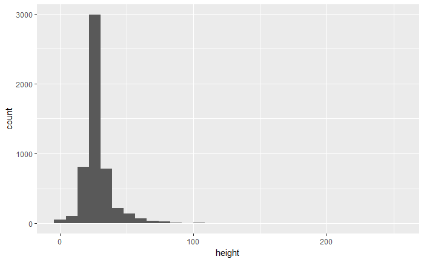

```r
ggplot() +
  geom_histogram(DamsTibble, mapping = aes(height))
ggsave("results/heighthistogram.png")
```

Almost all dam heights are below 100 feet and the the majority of dams are between 25-35 feet height.

### Question 18

The following code creates a bar plot for ownType variable from the high dams data set.

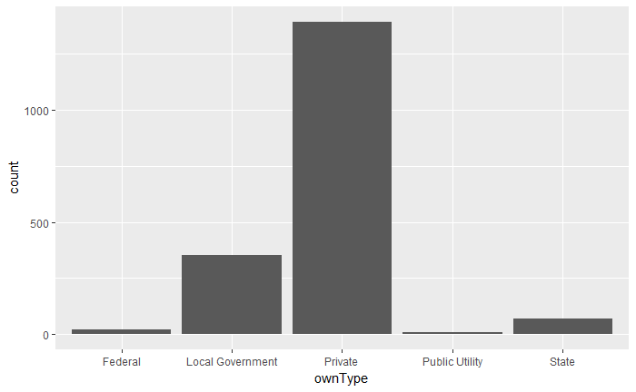

```r
ggplot() +
  geom_bar(HighDamsTibble, mapping = aes(ownType))
```

Private ownership is the most frequent type of dam ownership, local government ownership is in the second place with a dramatic drop in number and the number of state owned dams, which comes in the third place, is even lower.In the forth place is taken by the Federal owned dams and the public utility dams are at the last place.